# Health Characteristics across Canada

Noushin Nabavi

19 August, 2019

### Load dependencies

Identify libraries that are used for this project and load them.

```r
library(cansim) ## install.packages("cansim") if non-existent
library(tidyverse)
library(janitor)
library(naniar)
library(skimr)
library(sf)
library(rgdal)
library(leaflet)
library(mapview)
library(RColorBrewer)
library(factoextra)
library(NbClust)
```

### Retrieve data

Retrieve annual estimates for health characteristics in Canada from Statistics Canada Website available under CANSIM ID number 13-10-0096-01. The open data portal for health characteristics is available at (https://www150.statcan.gc.ca/t1/tbl1/en/tv.action?pid=1310009601).

```r
# load the data and clean names
data_summary_1 <- get_cansim("13-10-0096-01") %>%
  clean_names() %>%
  summary()

head(data_summary_1)
```

```
##    ref_date             geo               dguid
##  Length:148815      Length:148815      Length:148815
##  Class :character   Class :character   Class :character
##  Mode  :character   Mode  :character   Mode  :character
##
##
##
##   age_group             sex             indicators
##  Length:148815      Length:148815      Length:148815
##  Class :character   Class :character   Class :character
##  Mode  :character   Mode  :character   Mode  :character
##
##
##
##  characteristics        uom               uom_id
##  Length:148815      Length:148815      Length:148815
##  Class :character   Class :character   Class :character
##  Mode  :character   Mode  :character   Mode  :character
##
##
##
##  scalar_factor       scalar_id            vector
##  Length:148815      Length:148815      Length:148815
##  Class :character   Class :character   Class :character
##  Mode  :character   Mode  :character   Mode  :character
##
##
##
##   coordinate            value             status
##  Length:148815      Min.   :      -1   Length:148815
##  Class :character   1st Qu.:       6   Class :character
##  Mode  :character   Median :      60   Mode  :character
##                     Mean   :  170847
##                     3rd Qu.:   38100
##                     Max.   :28364200
##     symbol           terminated          decimals
##  Length:148815      Length:148815      Length:148815
##  Class :character   Class :character   Class :character
##  Mode  :character   Mode  :character   Mode  :character
##
```

[output cut: 15 more lines]

```
##
##  classification_code_for_indicators hierarchy_for_indicators
##  Length:148815                      Length:148815
##  Class :character                   Class :character
##  Mode  :character                   Mode  :character
##
##
##
##  classification_code_for_characteristics hierarchy_for_characteristics
##  Length:148815                           Length:148815
##  Class :character                        Class :character
##  Mode  :character                        Mode  :character
##
##
##
```

```r
# using skim() as an alternative to summary() to get overview of the data
data_summary_2 <- get_cansim("13-10-0096-01") %>%
  clean_names() %>%
  skim()

data_summary_2
```

```
## Skim summary statistics
##  n obs: 148815
##  n variables: 27
##
## ── Variable type:character ──────────────────────────────────────────────────────────────────
##                                 variable missing complete      n min max
##                                age_group       0   148815 148815  14  24
##                          characteristics       0   148815 148815   7  68
##        classification_code_for_age_group  148815        0 148815  NA  NA
##  classification_code_for_characteristics  148815        0 148815  NA  NA
##       classification_code_for_indicators  148815        0 148815  NA  NA
##              classification_code_for_sex  148815        0 148815  NA  NA
##                               coordinate       0   148815 148815   9  11
##                                 decimals       0   148815 148815   1   1
##                                    dguid   11925   136890 148815  11  11
##                                      geo       0   148815 148815   6  30
##                                  geo_uid   11925   136890 148815   2   2
##                  hierarchy_for_age_group       0   148815 148815   1   3
##            hierarchy_for_characteristics       0   148815 148815   1   1
##                 hierarchy_for_indicators       0   148815 148815   1   5
##                        hierarchy_for_sex       0   148815 148815   1   3
##                               indicators       0   148815 148815   6  87
##                                 ref_date       0   148815 148815   4   4
##                            scalar_factor       0   148815 148815   5   5
##                                scalar_id       0   148815 148815   1   1
##                                      sex       0   148815 148815   5  10
##                                   status  109278    39537 148815   1   2
##                                   symbol  148815        0 148815  NA  NA
##                               terminated  148815        0 148815  NA  NA
##                                      uom       0   148815 148815   6   7
##                                   uom_id       0   148815 148815   3   3
##                                   vector       0   148815 148815  10  10
##  empty n_unique
##      0        6
##      0        8
##      0        0
##      0        0
##      0        0
##      0        0
##      0    38367
```

[output cut: 10 more lines]

```
##      0        1
##      0        1
##      0        3
##      0        2
##      0        0
##      0        0
##      0        2
##      0        2
##      0    38367
##
## ── Variable type:numeric ────────────────────────────────────────────────────────────────────
##  variable missing complete      n      mean        sd p0 p25  p50   p75
##     value   23782   125033 148815 170847.44 879655.59 -1   6 59.9 38100
##     p100     hist
##  2.8e+07 ▇▁▁▁▁▁▁▁
```

```r
# make a summary of data in a new table
get_cansim("13-10-0096-01") %>%
  clean_names() %>%
  skim() %>%
  as.tibble()
```

```
## # A tibble: 193 x 6
##    variable type      stat     level  value formatted
##    <chr>    <chr>     <chr>    <chr>  <dbl> <chr>
##  1 ref_date character missing  .all       0 0
##  2 ref_date character complete .all  148815 148815
##  3 ref_date character n        .all  148815 148815
##  4 ref_date character min      .all       4 4
##  5 ref_date character max      .all       4 4
##  6 ref_date character empty    .all       0 0
##  7 ref_date character n_unique .all       4 4
##  8 geo      character missing  .all       0 0
##  9 geo      character complete .all  148815 148815
## 10 geo      character n        .all  148815 148815
## # … with 183 more rows
```

### Explore data and missing values

Check whether there are NA’s in the data and quantify missing values

```r
# save health_data and explore missingness
health_data <- get_cansim("13-10-0096-01") %>%
  clean_names()

# Explore explore the missingness
any_na(health_data)
```

```
## [1] TRUE
```

```r
n_miss(health_data)
```

```
## [1] 1049800
```

```r
prop_miss(health_data)
```

```
## [1] 0.2612739
```

```r
# summarizing missingness
health_data %>%
  miss_var_summary()
```

```
## # A tibble: 27 x 3
##    variable                                n_miss pct_miss
##    <chr>                                    <int>    <dbl>
##  1 symbol                                  148815   100
##  2 terminated                              148815   100
##  3 classification_code_for_age_group       148815   100
##  4 classification_code_for_sex             148815   100
##  5 classification_code_for_indicators      148815   100
##  6 classification_code_for_characteristics 148815   100
##  7 status                                  109278    73.4
##  8 value                                    23782    16.0
##  9 dguid                                    11925     8.01
## 10 geo_uid                                  11925     8.01
## # … with 17 more rows
```

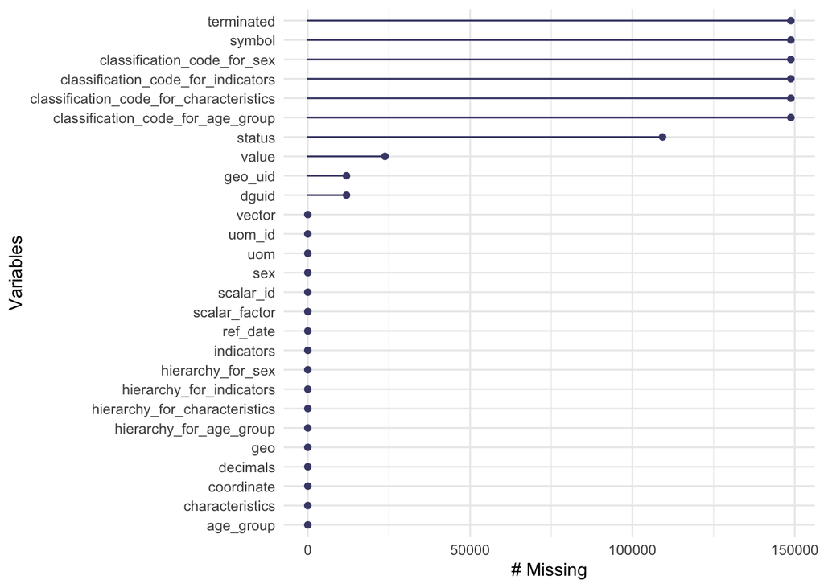

```r
# Visualize and cluster all of the missingness
# vis_miss(health_data, cluster = TRUE, warn_large_data = FALSE) ## reaches memory overload
gg_miss_var(health_data)
```

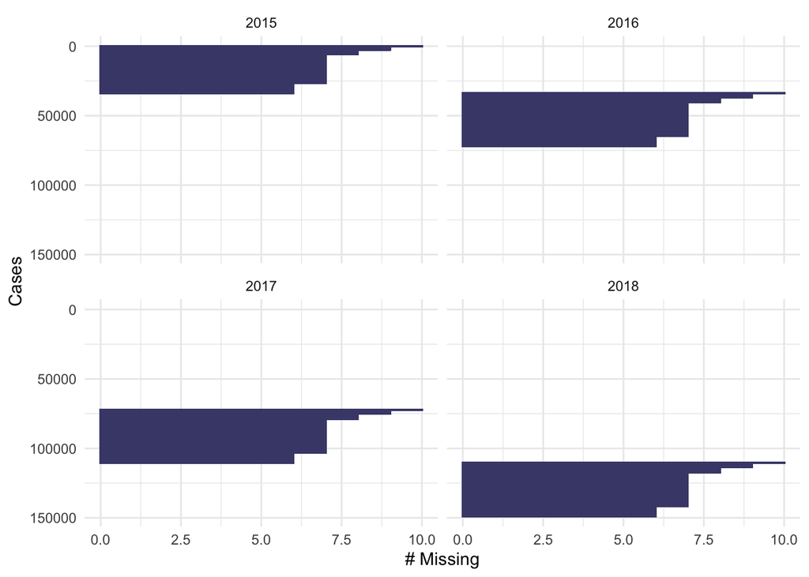

```r
# ggplot of the number of missings in all ref_date cases (rows).
gg_miss_case(health_data, facet = ref_date, order_cases = TRUE, show_pct = FALSE)
```

### Pre-process (wrangle) data

Explore fields and attributes of health data that are related to BC. The issue with taking either the percentage or number of persons per indicator is that there are multiple similar indicators within the same year and province. In order to plot the indicators, we are making the assumption that the same indicators can be added for one year in the same province.

```r
# clean headers and select columns/rows of interest for BC
bc_ind_no <- health_data %>%
  clean_names() %>%
  select(ref_date, geo, indicators, characteristics, value) %>%
  filter(characteristics == "Number of persons") %>%
  filter(geo == "British Columbia") %>%
  select(ref_date, geo, indicators, value) %>%
  na.omit()

# Factorize the data and check the number of indicators
bc_ind_no$indicators <- factor(bc_ind_no$indicators)
levels(bc_ind_no$indicators)
```

```
##  [1] "Arthritis (15 years and over)"
##  [2] "Asthma"
##  [3] "Body mass index, adjusted self-reported, adult (18 years and over), obese"
##  [4] "Body mass index, adjusted self-reported, adult (18 years and over), overweight"
##  [5] "Body mass index, self-reported, youth (12 to 17 years old), overweight or obese"
##  [6] "Breast milk feeding initiation"
##  [7] "Chronic obstructive pulmonary disease (COPD; 35 years and over)"
##  [8] "Contact with a medical doctor in the past 12 months"
##  [9] "Current smoker, daily"
## [10] "Current smoker, daily or occasional"
## [11] "Diabetes"
## [12] "Exclusive breastfeeding, at least 6 months"
## [13] "Fruit and vegetable consumption, 5 times or more per day"
## [14] "Has a regular healthcare provider"
## [15] "Heavy drinking"
## [16] "High blood pressure"
## [17] "Influenza immunization in the past 12 months"
## [18] "Life satisfaction, satisfied or very satisfied"
## [19] "Mood disorder"
## [20] "Perceived health, fair or poor"
## [21] "Perceived health, very good or excellent"
## [22] "Perceived life stress, most days quite a bit or extremely stressful"
## [23] "Perceived mental health, fair or poor"
## [24] "Perceived mental health, very good or excellent"
## [25] "Self-reported physical activity, 150 minutes per week, adult (18 years and over)"
## [26] "Self-reported physical activity, average 60 minutes per day, youth (12 to 17 years old)"
## [27] "Sense of belonging to local community, somewhat strong or very strong"
```

```r
# take a look at top 10 rows of data for BC indicators based on number of cases per indicator
head(bc_ind_no, n =10)
```

```
## # A tibble: 10 x 4
##    ref_date geo         indicators                                    value
##    <chr>    <chr>       <fct>                                         <dbl>
##  1 2015     British Co… Perceived health, very good or excellent     2.43e6
##  2 2015     British Co… Perceived health, fair or poor               4.46e5
##  3 2015     British Co… Perceived mental health, very good or excel… 2.65e6
##  4 2015     British Co… Perceived mental health, fair or poor        2.43e5
##  5 2015     British Co… Perceived life stress, most days quite a bi… 8.00e5
##  6 2015     British Co… Body mass index, adjusted self-reported, ad… 1.24e6
##  7 2015     British Co… Body mass index, adjusted self-reported, ad… 7.07e5
##  8 2015     British Co… Body mass index, self-reported, youth (12 t… 5.41e4
##  9 2015     British Co… Arthritis (15 years and over)                7.63e5
## 10 2015     British Co… Diabetes                                     2.45e5
```

```r
# Aggregate/clean data: add number of persons with same indicator per year
bc_ind <- bc_ind_no %>%
  group_by(ref_date, indicators) %>%
  mutate(value_b = sum(value)) %>%
  select(ref_date, indicators, value_b) %>%
  distinct(indicators, .keep_all = TRUE)

# take a look at top 10 rows of cleaned data for BC
head(bc_ind, n =10)
```

```
## # A tibble: 10 x 3
## # Groups:   ref_date, indicators [10]
##    ref_date indicators                                              value_b
##    <chr>    <fct>                                                     <dbl>
##  1 2015     Perceived health, very good or excellent                 9.70e6
##  2 2015     Perceived health, fair or poor                           1.77e6
##  3 2015     Perceived mental health, very good or excellent          1.06e7
##  4 2015     Perceived mental health, fair or poor                    9.60e5
##  5 2015     Perceived life stress, most days quite a bit or extrem…  3.20e6
##  6 2015     Body mass index, adjusted self-reported, adult (18 yea…  4.96e6
##  7 2015     Body mass index, adjusted self-reported, adult (18 yea…  2.83e6
##  8 2015     Body mass index, self-reported, youth (12 to 17 years …  2.16e5
##  9 2015     Arthritis (15 years and over)                            3.05e6
## 10 2015     Diabetes                                                 9.67e5
```

```r
# Get Proportion of individuals with certain indicators
bc_ind_prop <- bc_ind %>%
  mutate(Proportion = value_b/sum(bc_ind$value_b)* 100) %>%
  arrange(desc(Proportion))
```